# Urban Legend: HashCode

## Ассоциативный массив

[figure not shown]

примеры:

- словарь
- телефонный справочник
- подсчёт слов в статье
- и т.д.

## Ассоциативный массив: put(key1, value1)

[figure not shown]

## Ассоциативный массив: put(key2, value2)

[figure not shown]

## Ассоциативный массив: put(key3, value3)

[figure not shown]

## Ассоциативный массив: get(key3)

[figure not shown]

## Можно ли лучше ?

[figure not shown]

## javadoc:

### java.lang.Object

`public int hashCode()`

Returns a hash code value for the object. This method is supported for the benefit of hash tables such as those provided by **HashMap**.

// …

[https://docs.oracle.com/javase/8/docs/api/java/lang/Object.html](https://docs.oracle.com/javase/8/docs/api/java/lang/Object.html#hashCode--)

## hashCode и equals

- **Симметричность**:
  - для ∀ **a** ≠ *null* и ∀ **b** ≠ *null*: **a**.equals(**b**) ⇔ **b**.equals(**a**)
- **Рефлексивность**:
  - для ∀ **a** ≠ *null* ⇒ **a**.equals(**a**)
- **Транзитивность**:
  - eсли **a**.equals(**b**) и **b**.equals(**c**) ⇒ **a**.equals(**c**)
- **Совместимость** с hashCode():
  - если **a**.equals(**b**) ⇒ **a**.hashCode() == **b**.hashCode()

## hashMap.put( key1, value1 )

[figure not shown]

## hashMap.get( key1 )

[figure not shown]

## hashMap.get( key2 )

[figure not shown]

## Контракт hashCode

- неизменчивость и постоянство

```
Whenever it is invoked on the same object more than once during
an execution of a Java application, the hashCode method must
consistently return the same integer, provided no information
used in equals comparisons on the object is modified.

...
```

[https://docs.oracle.com/javase/8/docs/api/java/lang/Object.html](https://docs.oracle.com/javase/8/docs/api/java/lang/Object.html#hashCode--)

## нарушение контракта hashCode

[figure not shown]

## Сложность поиска / вставки

[figure not shown]

## Коллизии

[figure not shown]

## Разрешение коллизий - chaining

[figure not shown]

## свойства hashCode

- неизменчивость и постоянство
- *хорошее* распределение == меньше коллизий

## Object.hashCode - утёкшая абстракция

```java
Object object = new Object();

assert object.hashCode() == System.identityHashCode(object);
```

## Urban Legend: Первоисточник

### java.lang.Object

`public int hashCode()`

// …

*This is typically implemented by converting the **internal address of the object** into an integer, but this implementation technique is not required by the JavaTM programming language.*

[https://docs.oracle.com/javase/8/docs/api/java/lang/Object.html](https://docs.oracle.com/javase/8/docs/api/java/lang/Object.html#hashCode--)

## Urban Legend:

```java
package java.lang;

public class Object {

    // ...

    public int hashCode(){
      return &this;
    }

}
```

## sun.misc.Unsafe ?

## Java Object Layout !

```java
VirtualMachine vm = VM.current();
long address = vm.addressOf(object);

long size = vm.sizeOf(object);

for (int offset = 0; offset < size; offset += 4) {
  int dump = vm.getInt(object, offset);
}
```

## ObjectReallocation demo:

```java
Object object = new Object();
long address = getAddress(object);
int hashCode = object.hashCode();

list.add(object);

for(int i = 0; ; i++) {
    Object o = new Object();
    list.add(o);

    long address2 = getAddress(object);

    if (address != address2) {
      int hashCode2 = object.hashCode();
      throw new RuntimeException();
    }
}
```

## ObjectReallocation demo:

```java
Object object = new Object();
long address = getAddress(object);

list.add(object);

for(int i = 0; ; i++) {
    Object o = new Object();
    list.add(o);

    long address2 = getAddress(object);

    if (address != address2) {
      throw new RuntimeException();
    }
}
```

`-verbose:gc -XX:+PrintGC -XX:+PrintGCDetails`

## Object.hashCode() ?

```java
package java.lang;

public class Object {

    // ............

    public native int hashCode();

}
```

## ObjectMemoryDump - читаем заголовок

[figure not shown]

Intel X86: Little Endian

## ObjectMemoryDump - читаем заголовок

[figure not shown]

`-XX:hashCode=4`

## Адресное пространство объекта

[figure not shown]

## Упрощённый memory allocation

```c
private char *memory_pointer;

public void * malloc(long size)
{
    char *old = memory_pointer;

    memory_pointer += size;

    return (void *)old;
}
```

## Навалим в кучу

```bash
$ java -XX:+PrintFlagsFinal -version | \
            egrep  "(InitialHeapSize|MaxHeapSize)"

    uintx InitialHeapSize    := 268 435 456
    uintx MaxHeapSize        := 4 294 967 296

java version "1.8.0_112"
```

```java
long freeMemory = Runtime.getRuntime().freeMemory();

239 942 568
```

`239 942 568 / 16 = 14 996 410.5`

→ должно хватить как минимум на **14 млн** объектов

## IdentityHashCodeCollision demo:

```java
Set<Integer> codes = new HashSet<>();
List list = new ArrayList();

for(int i = 0; ; i++){
    Object obj = new Object();
    list.add(obj);

    int hashCode = obj.hashCode();

    if (!codes.add(hashCode))
        throw new RuntimeException();

}
```

`-XX:hashCode=4`

## ThreadedIdentityHashCodeCollision demo:

```java
new Thread(new Runnable() {
    public void run() {
        for (int i = 0; ; i++) {

            final Object object = new Object();

            synchronized (list) {
                list.add(object);
                int hashCode = object.hashCode();
                if (!codes.add(hashCode))
                    throw new RuntimeException();
            }
        }
    }
}).start();
```

`-XX:hashCode=4`

## Немного исправленный наивный malloc

- нужен `synchronized` или `Compare-And-Swap`

```c
private char *memory_pointer;

public synchronized void * malloc(long size)
{
    char *old = memory_pointer;

    memory_pointer += size;

    return (void *)old;
}
```

⇒ высокий `contention` при аллокации

## Thread Local Allocation Buffer

[figure not shown]

## IdentityHashCodeCollision demo:

```java
Set<Integer> codes = new HashSet<>();
List list = new ArrayList();

for(int i = 0; ; i++){
    Object obj = new Object();
    list.add(obj);

    int hashCode = obj.hashCode();

    if (!codes.add(hashCode))
        throw new RuntimeException();

}
```

`-XX:hashCode=4 -XX:+PrintTLAB`

## Стоимость TLAB

```java
    @Benchmark
    public Object allocate() {
       return new Object();
    }
```

## Стоимость TLAB

```java
    @Benchmark
    public Object allocate() {
       return new Object();
    }
```

| Benchmark | Opts | Score | Error | Units |
| --- | --- | --- | --- | --- |
| AllocationPerfTest.allocate | -XX:+UseTLAB | 4.155 | 0.090 | ns/op |
| AllocationPerfTest.allocate | -XX:-UseTLAB | 11.939 | 0.277 | ns/op |

**TLAB** → 3x быстрее аллокация

## Object.hashCode: кто же ты ?

## -XX:hashCode

| -XX:hashCode=k | Тип |
| --- | --- |
| 0 | [Park-Miller генератор случайных чисел](https://en.wikipedia.org/wiki/Lehmer_random_number_generator), *по умолчанию* |
| 1 | fn(адрес объекта, глобальное состояние) |
| 2 | константа 1 |
| 3 | последовательный счетчик |
| 4 | адрес объекта |
| 5 | Thread-local Xorshift |

## Распределение identity hashCode

10 млн объектов в 10 нитях:

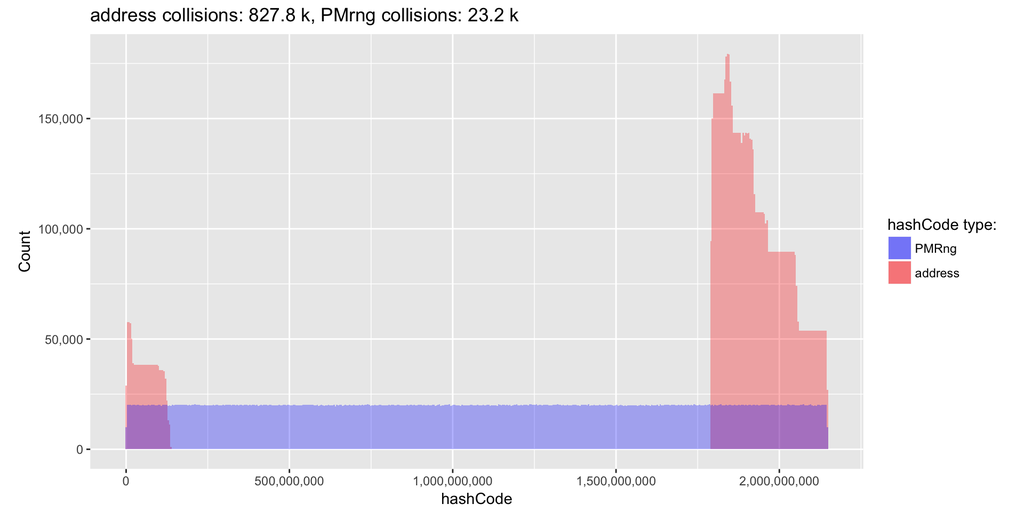

## Плохой выбор

Использование адреса в качестве hashCode

- объекты перемещаются
- много коллизий
- адреса выравнены → сужение вариантов

## Beyond the legend

## Функции масштабирования

- `hashCode % array.length`
  - `array.length` - простое число, исп. *Trove*

## Функции масштабирования

- `hashCode & mask`
  - исп. *Java Collections*, *Koloboke* и д.р.

если `array.length` = 2<sup>k</sup>

[figure not shown]

`hashCode % array.length = hashCode & (array.length - 1)`

## hashCode() и данные

```java
String s1 = new String("java");

String s2 = new String("java");

assert s1.hashCode() == s2.hashCode();

Integer i1 = new Integer(42);

Integer i2 = new Integer(42);

assert i1.hashCode() == i2.hashCode();
```

## простой hashCode

```java
public class Point {
    public int x, y;

    @Override
    public int hashCode(){
        return 31 * x + y;
    }

    @Override
    public boolean equals(Object o) {
        if (this == o) return true;
        if (!(o instanceof Point)) return false;

        Point point = (Point) o;

        return x == point.x && y == point.y;
    }
}
```

## типичный hashCode

```java
public final class String {
    private final char value[];
    private int hash;

    public int hashCode() {
        int h = hash;
        if (h == 0 && value.length > 0) {
            char val[] = value;

            for (int i = 0; i < value.length; i++) {
                h = 31 * h + val[i];
            }
            hash = h;
        }
        return h;
    }
}
```

## Парадокс дней рождений

## Парадокс дней рождений

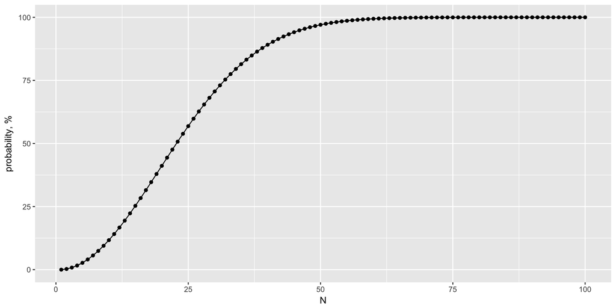

## Парадокс дней рождений для hashCode

\[p_{uniq}(n) = \left({1 - \frac{1}{2^{32}}}\right)\cdot\left({1 - \frac{2}{2^{32}}}\right)\cdot\ldots\cdot\left({1 - \frac{n - 1}{2^{32}}}\right) =\] \[ = \frac{2^{32}}{2^{32 n} \cdot (2^{32} - n)!}\]

\[ \Rightarrow 1 - p_{uniq}(n) \approx 0.5, при \ n = 77\ 170\]

Wolfram Alpha

\[ \Rightarrow 1 - p_{uniq}(n) \approx 0.99, при\ n = 200\ 000\] Wolfram Alpha

## далеко ходить не надо

```java
assert "Aa".hashCode() == "BB".hashCode();
```

## Comparable

```java
public interface Comparable<T> {
    public int compareTo(T o);
}
```

например:

```java
public final class String
    implements java.io.Serializable, Comparable<String>, CharSequence {
    ///
}
```

```java
public final class Integer extends Number
    implements Comparable<Integer> {
    ///
}
```

*и другие…*

## Бинарное дерево поиска

[figure not shown]

## Low contention - Biased Locking

[figure not shown]

## Biased Locking demo:

```java
        Object object = new Object();

        String dump0 = dump(object);

        final List list = new ArrayList();

        synchronized (object) {
            list.add(object);
        }

        String dump1 = dump(object);

        int hashCode = System.identityHashCode(object);

        String dump2 = dump(object);
```

`-XX:BiasedLockingStartupDelay=0`

## Biased Locking demo:

[figure not shown]

`-XX:BiasedLockingStartupDelay=0`

## Biased Locking - Counter:

```java
    public class Counter {
        private long count = 0l;

        public synchronized long incAndGet() {
            return ++count;
        }
    }
```

## BiasedLockingPerfTest

```java
Counter counter, counterWithSysIdHashCode;

@Benchmark
public long increment() {
    return counter.incAndGet();
}

@Benchmark
public long incrementWithSysIdHashCode() {
    return counterWithSysIdHashCode.incAndGet();
}

@Setup
public void setup(Blackhole bh) {
    counter = new Counter();
    counterWithSysIdHashCode = new Counter();
    bh.consume(System.identityHashCode(counterWithSysIdHashCode));
}
```

## BiasedLockingPerfTest результаты

`-XX:+UseBiasedLocking`

| Benchmark | Score | Error | Units |
| --- | --- | --- | --- |
| BiasedLockingPerfTest.increment | 5.799 | 0.148 | ns/op |
| BiasedLockingPerfTest.incrementWithSysIdHashCode | 25.279 | 1.054 | ns/op |

`-XX:-UseBiasedLocking`

| BiasedLockingPerfTest.increment | 24.994 | 0.895 | ns/op |
| --- | --- | --- | --- |
| BiasedLockingPerfTest.incrementWithSysIdHashCode | 25.121 | 0.976 | ns/op |

## Заключение

- HashMap - быстро
- HashCode - не адрес
  - В JVM есть GC, TLAB
- `System.identityHashCode` - плохо
  - Biased locking
- Переопределяйте `hashCode` и `equals`
  - простые числа для множителей - хорошо
  - чётные числа для множителей и битовые операции - плохо
- и ещё лучше определяйте `compareTo`

## Q/A

## Контакты

### слайды и примеры: github.com/vladimirdolzhenko/hashCodeLegend

### email: vladimir.dolzhenko@gmail.com

### twitter: [@dolzhenko](https://twitter.com/dolzhenko)